# Book Genre Prediction using machine learning

## prepared by Karol Wesolowski

### Learning task and preparation

The task of the algorithm is to predict a genre of a book based on a blurp. Blurp is a short description of a piece created by publisher, to promote the book and show the general content of it. Genre is usually a broad category used to classify books by sellers.

Data for the task comes from Kaggle and is presented in the form of csv file.

To perform the task it is required to use many python packages. For machine learning computations I used packages from sklearn family. For text analysis I used nltk package. Data is saved into Panda DataFrame format. Math operation using Numpy, to measure time I used default python time package. Graphs generated using pyplot and Seaborn. To improve computation time, I used Counter from collections package to create "bag of words".

### Data

```python
data = pd.read_csv("data.csv", index_col=0)
print(data.head())
```

```
                           title    genre  \
index
0              Drowned Wednesday  fantasy
1                  The Lost Hero  fantasy
2      The Eyes of the Overworld  fantasy
3                Magic's Promise  fantasy
4                 Taran Wanderer  fantasy

                                                 summary
index
0       Drowned Wednesday is the first Trustee among ...
1       As the book opens, Jason awakens on a school ...
2       Cugel is easily persuaded by the merchant Fia...
3       The book opens with Herald-Mage Vanyel return...
4       Taran and Gurgi have returned to Caer Dallben...
```

Data consist of four columns:

- Index: Integer, not used in computation;
- Title: String, not used in computation;
- Genre: Enum String, proper generation of this field is the goal of the computation
- Summary: long String, blurp content, data used in computation

```python
print("shape of the data frame ", data.shape)
print("does it contains missing values?\n", data.isna().any(), "\n_______")
```

```
shape of the data frame  (4657, 3)
does it contains missing values?
 title      False
genre      False
summary    False
dtype: bool
_______
```

```python
genres = data.groupby(["genre"])["genre"].count().sort_values(ascending=False)
print(genres)
```

```
genre
thriller      1023
fantasy        876
science        647
history        600
horror         600
crime          500
romance        111
psychology     100
sports         100
travel         100
Name: genre, dtype: int64
```

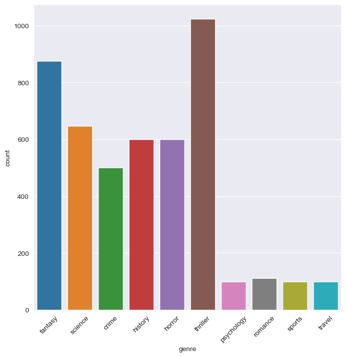

```python
plt.figure(figsize=(8, 8))
g = sns.countplot(x="genre", data=data)
plt.xticks(rotation=45)
fig = g.get_figure()
plt.show()
```

For convenience reasons, graph generating code in original file is saved into a function `graph(data)`, and its output is saved to a png file.

Next step in the computation is to clean the data and prepare it to text analysis. Every summary is sent to `nlp_cleaning` function, which performs following steps:

1. turn every word to lower case
2. split words into tokens
3. remove all tokens that are not "words" (e.g. numbers)
4. remove english stopwords downloaded from `nltk.corpus.stopwords`
5. convert nouns into singular
6. convert verbs into base form

Generated stems (processed tokens) are added to 'data' DataFrame as "clean" column. Because this function is very slow and time-consuming, its result is saved to csv file, and is meant to run only once. To follow progress it prints a dot ('.') every time it finishes computing.

```python
def nlp_cleaning(data, output_filename):
    english_stops = set(stopwords.words("english"))
    wl = WordNetLemmatizer()
    new_col_stems = []
    for summary in data["summary"]:
        print(".", end="")
        tokens = word_tokenize(summary.lower())  # split into tokens
        letters_only = [token for token in tokens if token.isalpha()]  # remove non-alpha
        no_stops = [token for token in letters_only if token not in english_stops]  # remove stop words
        stems = [wl.lemmatize(token) for token in no_stops]  # remove plural forms
        stems = [wl.lemmatize(token, 'v') for token in stems]  # change verbs to base form
        new_col_stems.append(stems)
    data["clean"] = new_col_stems
    data.to_csv(output_filename)
```

To show the result I am using an excerpt of original data, containing first ten rows.

```python
small = pd.read_csv("small.csv", index_col=0)
nlp_cleaning(small, "small_out.csv")
print("\n", small.head(3))
```

[output not shown]

Processed data is then reloaded into program.

### Literary Overview

The scientific paper Book Genre Prediction by Priyal Desai et al. suggest using logistic regression to solve the same problem on larger scale. In their implementation they allow a book to belong to many genres, which is how it usually works in real life. Books and movies have traits, that allows them to be considered as parts of many categories, yet there always should be one, that is the most important. It isn't always the most clearly visible genre, and thus the algorithm is not expected to have 100% accuracy. Because of existence of multiple categories it is best to use One vs Rest classifier.

Authors of the paper also suggested, that using unsupervised learning technics may provide better results and can be considered more useful, due to its ability to work with raw data. But because I have a dataset with clearly classified records, it is much simpler to use supervised learning methods (which is also the point of the authors - precategorized data is easy to obtain from retailers and publishers)

Other works covering this topic suggest using multiple models and choosing one that creates the best results. That is the way I chose. I took four models: Logistic regression, because it was suggested by the most works, K-nearest neighbours for its simplicity, Multinomial Naive Bayes, due to how good it works with multicategorical data and Support Vector classifier, because it is considered the best for text analysis.

The main function of the program is called `fit`. Based on data and a list of models, it creates predictions, calculates accuracy and F1 score and finally presents the result as confusion matrix. Function is executed by the following code:

```python
def fit(X_train, X_test, y_train, y_test, old_labels, classifier):
    ans = []
    name = str(classifier).split('.')[-1][:-2]
    models = [KNeighborsClassifier(), LogisticRegression(), MultinomialNB(), SVC()]
    graph, axes = plt.subplots(len(models)//2, 2, figsize=(18,12))
    graph.suptitle(name, size=24)
    graph.tight_layout(pad=5.0)
    for i, model in enumerate(models):
        model = classifier(model)
        start = time.process_time()
        model.fit(X_train, y_train)
        pred = model.predict(X_test)
        fin = time.process_time()
        ac = accuracy_score(pred, y_test)
        f1 = f1_score(pred, y_test, average="macro")

        ans.append([str(model), ac, f1, (fin - start) * 1000])

        cfm = confusion_matrix(y_test, pred)

        # Generate graph
        fig = sns.heatmap(cfm / cfm.sum(axis=1)[:, None] * 100, ax=axes[i//2, i%2], annot=True, cmap='Greens', vmax=100)
        fig.tick_params(labelrotation=45)
        fig.xaxis.set_ticklabels(old_labels)
        fig.yaxis.set_ticklabels(old_labels)
        title = str(model).split('=')[1][:-3]
        fig.title.set_text(title)

    df = pd.DataFrame(ans, columns=["model", "accuracy", "F1 score", "time ms"])
    graph.savefig(name+".png")
    return df
```

```python
# Preparation
data = pd.read_csv("out.csv")
encoder = LabelEncoder()
data["genre"] = encoder.fit_transform(data["genre"])
old_labels = dict(zip(encoder.classes_, range(len(encoder.classes_))))
X_data = CountVectorizer().fit_transform(data["clean"])
X_train, X_test, y_train, y_test = train_test_split(X_data, data["genre"], test_size=0.25, random_state=79)
```

```
                                               model  accuracy  F1 score  \
0  OneVsRestClassifier(estimator=KNeighborsClassi...  0.238627  0.180809
1  OneVsRestClassifier(estimator=LogisticRegressi...  0.660944  0.631467
2     OneVsRestClassifier(estimator=MultinomialNB())  0.657511  0.457946
3               OneVsRestClassifier(estimator=SVC())  0.648069  0.616147

      time ms
0    6593.750
1   31125.000
2     218.750
3  111984.375
```

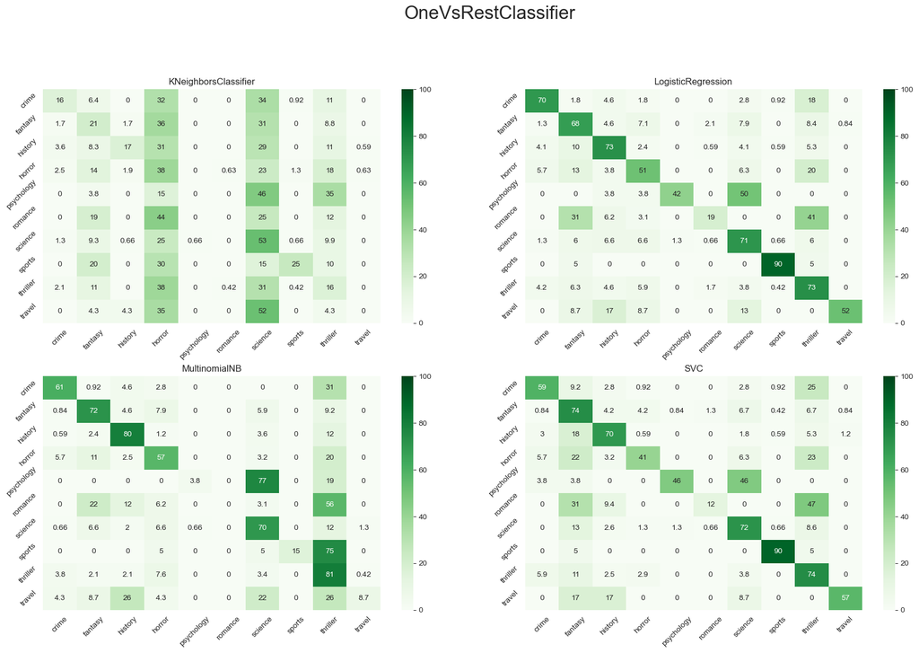

```python
# Execution
df = fit(X_train, X_test, y_train, y_test, old_labels, OneVsRestClassifier)
print(df)
```

I also decided to try One vs One classifier to check if the results will be better.

```
                                               model  accuracy  F1 score  \
0  OneVsOneClassifier(estimator=KNeighborsClassif...  0.265236  0.159417
1  OneVsOneClassifier(estimator=LogisticRegressio...  0.651502  0.621781
2      OneVsOneClassifier(estimator=MultinomialNB())  0.660944  0.421970
3                OneVsOneClassifier(estimator=SVC())  0.495279  0.313913

     time ms
0   11593.75
1   75562.50
2     687.50
3  108343.75
```

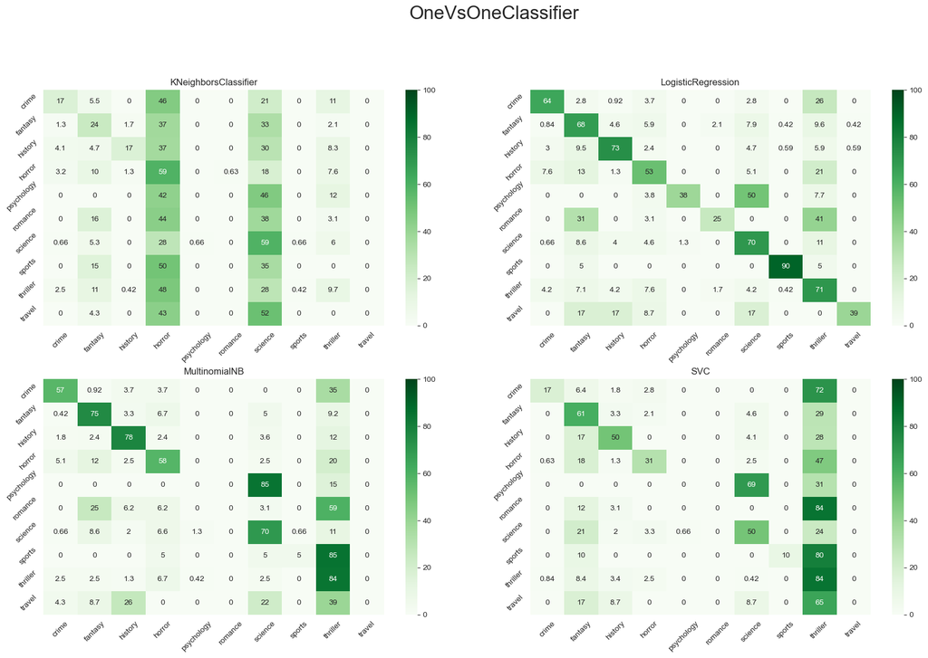

```python
df = fit(X_train, X_test, y_train, y_test, old_labels, OneVsOneClassifier)
print(df)
```

### Output

Output generated by the functions consist of couple parts. First is the dictionary of most popular tokens in each genre. As can be seen, some of them repeat over many categories (words like 'one', 'take' or 'find'), which may lead (and very likely leads) to confusion and mistakes in classification.

```python
data = pd.read_csv("out.csv")
words_dict_by_genre(data)
```

```
history: [('take', 808), ('one', 648), ('find', 639), ('father', 582), ('return', 557), ('make', 552), ('become', 519), ('tell', 515), ('go', 508), ('life', 499)]
travel: [('travel', 95), ('world', 65), ('life', 60), ('journey', 50), ('one', 49), ('new', 48), ('people', 43), ('book', 41), ('year', 41), ('time', 40)]
sports: [('one', 116), ('l', 99), ('team', 81), ('get', 69), ('life', 68), ('know', 66), ('new', 62), ('player', 57), ('want', 57), ('make', 54)]
crime: [('find', 761), ('murder', 709), ('one', 556), ('kill', 468), ('take', 446), ('go', 445), ('man', 404), ('miss', 376), ('tell', 375), ('police', 326)]
science: [('one', 719), ('time', 677), ('human', 599), ('take', 595), ('find', 575), ('world', 539), ('ship', 485), ('planet', 484), ('earth', 458), ('make', 445)]
horror: [('kill', 867), ('find', 851), ('one', 759), ('go', 669), ('take', 603), ('vampire', 590), ('anita', 540), ('begin', 509), ('tell', 505), ('make', 466)]
thriller: [('one', 1039), ('find', 1011), ('kill', 811), ('take', 672), ('go', 639), ('life', 621), ('new', 610), ('two', 536), ('murder', 525), ('know', 525)]
psychology: [('book', 94), ('people', 78), ('new', 75), ('life', 69), ('make', 64), ('u', 63), ('work', 57), ('way', 50), ('one', 48), ('world', 48)]
romance: [('love', 112), ('one', 111), ('l', 111), ('life', 84), ('new', 72), ('know', 67), ('make', 52), ('time', 45), ('find', 42), ('year', 40)]
fantasy: [('find', 1087), ('one', 1017), ('take', 835), ('kill', 655), ('go', 645), ('world', 634), ('time', 615), ('make', 608), ('king', 602), ('life', 601)]
```

#### One Vs Rest

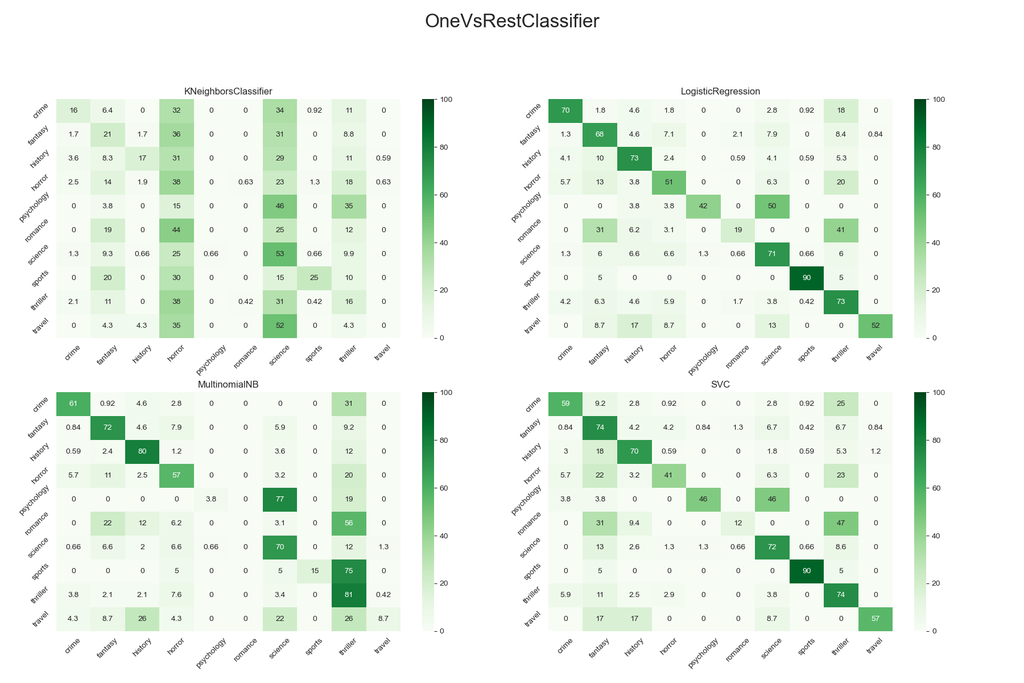

K-nearest Neighbor classifier fails completely, reaching a little more than 20% accuracy. Results are quite random, most of the books got classified either as 'Horror', or as 'Science' (even though less than half of Horror books are classified correctly). Logistic Regression proved to be the best possible model, with 66% accuracy and F1 score at 0.63. There are some problems, for example with 'Psychology' (but it is a very small genre), 'Romance' (same reason) and 'Horror', which gets confused with 'Fantasy' and 'Thriller'. It is not a bad result, considering how closely related those genres are in real life. It is also quite slow model.

```python
def fit_best(X_train, X_test, y_train, y_test, c):
    model = OneVsRestClassifier(LogisticRegression(C=c))
    start = time.process_time()
    model.fit(X_train, y_train)
    pred = model.predict(X_test)
    fin = time.process_time()
    ac = accuracy_score(pred, y_test)
    f1 = f1_score(pred, y_test, average="macro")
    ans = [c, ac, f1, (fin - start) * 1000]
    return ans
```

```python
res = []
for c in range(1,11):
    res.append(fit_best(X_train, X_test, y_train, y_test, c/10))
df = pd.DataFrame(res, columns=["reg. param.", "accuracy", "F1 score", 'time [ms]'])
print(df)
```

```
   reg. param.  accuracy  F1 score  time [ms]
0          0.1  0.670386  0.633337  19015.625
1          0.2  0.666094  0.636749  20812.500
2          0.3  0.664378  0.635697  23031.250
3          0.4  0.660944  0.633087  22453.125
4          0.5  0.660944  0.630985  23843.750
5          0.6  0.660086  0.630174  25562.500
6          0.7  0.660944  0.630893  25375.000
7          0.8  0.660944  0.631102  25781.250
8          0.9  0.660944  0.631280  27437.500
9          1.0  0.660944  0.631467  29484.375
```

To check the results further, I run the code on 50 different sets of test/train combinations. After around 3 hours of computation time, the achieved results are still very similar, with accuracy on average equal to 67% and F1 score at about 0.63, although in some cases, accuracy reached 70% (for example for random state of 13 and c= 0.4)

```
reg. param.  acc       F1
0.1          0.677888  0.624842
0.2          0.676721  0.631209
0.3          0.675296  0.632116
0.4          0.673597  0.631761
0.5          0.672670  0.631601
0.6          0.671983  0.631362
0.7          0.671107  0.630901
0.8          0.670146  0.630295
0.9          0.669682  0.630086
1.0          0.669219  0.629617
```

#### One Vs One

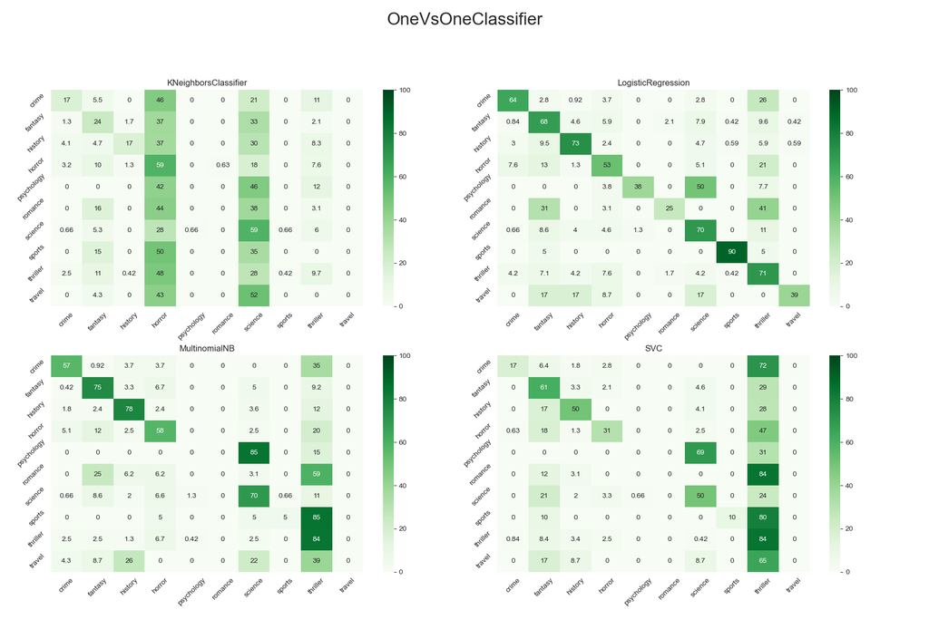

### Summary

As I suspected, reaching 70% accuracy is in general not possible. The answers I got are good enough, considering the nature of data, and the limitations of dataset. In original form, presented in abovementioned article, problem allows a book to belong to multiple categories. That way it would be possible to limit wrong classification, by simply assigning two genres to one book. In many cases, seen in the graphs above, those double categories would make sense. In my opinion this program could be useful for retailers, who want to categorize books they sell. It may work better, if the data is more equally distributed. This analysis also proves, that artificial intelligence algorithms are able to recognize a genre of given text, so it would be interesting to see, if they work as good with real text, not only with blurp, whose goal is to inform reader about the interior of th book. My calculation doesn't take title into consideration. It may improve the results, or may make it worse, considering many titles reflects the content only partialy, or in a metaphorical way (Consider "Where the Crawdads Sing", romance/criminal book, whose title may suggest something about biology).

Thank You for your attention

Prepared by Karol Wesołowski

Data: https://www.kaggle.com/datasets/athu1105/book-genre-prediction

Paper: https://www.academia.edu/download/78317246/Book_Genre_Prediction.pdf